# K-Means Clustering Project - Spin Class Attendees

In this exercise, we'll be using the K-Means Clustering algorithm to segment a rider base of over 500 spin class attendees into natural groupings. **K-Means** is a method of segmenting a dataset in which each data point is placed into one of *K* clusters so that each observation belongs to the cluster with the nearest *centroid*, i.e. the mean of the cluster. In practice, this means that the data points within each cluster are most similar to each other, and less similar to data points in the other clusters. Let's get started on our exercise:

## 1. Data Preparation

We'll begin by importing the requisite libraries:

```python
import pandas as pd

import matplotlib.pyplot as plt
import mplcursors
import seaborn as sns

from sklearn import preprocessing
from sklearn.cluster import KMeans
from sklearn.metrics import silhouette_score
from sklearn.decomposition import PCA
import numpy as np

# Default to centering matplotlib within the notebook
from IPython.core.display import HTML
HTML("""
<style>
.output_png {
    display: table-cell;
    text-align: center;
    vertical-align: middle;
}
</style>
""")

import pyodbc
import warnings
import joblib

warnings.filterwarnings("ignore")
```

And then by connecting to the local "Spin Class" SQL Server database:

```python
conn = pyodbc.connect('DRIVER={ODBC Driver 17 for SQL Server};'
                      'SERVER=localhost;'
                      'DATABASE=SpinClass;'
                      'UID=ANDREWACER\andre;'
                      'Trusted_Connection=yes;')
cursor = conn.cursor()
```

Let's query our "Riders" SQL view and turn the results into a DataFrame - this will contain a full dataset of participation information on each person who's ridden in one of my spin classes:

```python
sql = """
SELECT
[Rider ID],
[First Name],
[Last Name],
[Email],
[First Ride],
[Most Recent Ride],
[Most Recent Ride Format],
[Most Recent Ride Location],
[Most Recent Ride Playlist],
[Number of Rides],
[Number of Locations],
[Top Location],
[Number of Rides - Last Month],
[Number of Rides - Last Three Months],
[Number of Rides - Last Six Months],
[Number of Rides - Last Twelve Months],
[Days Between First and Last Ride],
[Days Since First Ride],
[Days Since Last Ride],
[Average Days Between Rides],
[Average Weeks Between Rides],
[Rides per Month]
FROM [SpinClass].[dbo].[Riders_Alias]

ORDER BY NEWID()
"""
df = pd.read_sql(sql,conn)
```

And let's take a quick peek at that data:

```python
df.head()
```

|  | Rider ID | First Name | Last Name | Email | First Ride | Most Recent Ride | Most Recent Ride Format | Most Recent Ride Location | Most Recent Ride Playlist | Number of Rides | ... | Number of Rides - Last Month | Number of Rides - Last Three Months | Number of Rides - Last Six Months | Number of Rides - Last Twelve Months | Days Between First and Last Ride | Days Since First Ride | Days Since Last Ride | Average Days Between Rides | Average Weeks Between Rides | Rides per Month |
| --- | --- | --- | --- | --- | --- | --- | --- | --- | --- | --- | --- | --- | --- | --- | --- | --- | --- | --- | --- | --- | --- |
| 0 | 404 | Eric | Derehow | xxxx@gmail.com | 2025-01-08 17:30:00 | 2025-01-08 17:30:00 | RockSTAR RIDE | Gold Coast | https://open.spotify.com/playlist/5IaZU8ieGX71... | 1 | ... | 0 | 0 | 0 | 0 | 0 | 177 | 177 | 0 | 0 | 0.166667 |
| 1 | 308 | Glen | Palkidis | xxxx@gmail.com | 2024-11-13 17:30:00 | 2024-11-13 17:30:00 | RockSTAR RIDE | Gold Coast | https://open.spotify.com/playlist/1vF0jhihy243... | 1 | ... | 0 | 0 | 0 | 0 | 0 | 233 | 233 | 0 | 0 | 0.125000 |
| 2 | 171 | Jim | McRlwain | xxxx@gmail.com | 2024-08-04 09:45:00 | 2025-06-22 09:45:00 | RockSTAR RIDE | West Loop | https://open.spotify.com/playlist/0DaKrURTnU9Y... | 30 | ... | 0 | 0 | 0 | 0 | 322 | 334 | 12 | 10 | 1 | 2.727273 |
| 3 | 224 | Mac | Loberts | xxxx@gmail.com | 2024-09-08 09:45:00 | 2025-02-16 09:45:00 | RockSTAR RIDE | West Loop | https://open.spotify.com/playlist/4ygIutnOUlYq... | 3 | ... | 0 | 0 | 0 | 0 | 161 | 299 | 138 | 53 | 7 | 0.272727 |
| 4 | 8 | Jody | Carpa | xxxx@gmail.com | 2023-11-27 17:45:00 | 2023-12-04 17:45:00 | RockSTAR RIDE | South Loop | https://open.spotify.com/playlist/4sfK4CvthxS2... | 2 | ... | 0 | 0 | 0 | 0 | 7 | 585 | 578 | 3 | 0 | 0.095238 |

5 rows × 22 columns

Now, let's pare this down to just the numerical variables we will plan on using for feature selection:

```python
features = df[['Rider ID','First Name','Last Name','Number of Rides','Number of Locations','Number of Rides - Last Month','Number of Rides - Last Three Months','Number of Rides - Last Six Months','Number of Rides - Last Twelve Months','Days Between First and Last Ride','Days Since First Ride','Days Since Last Ride','Average Days Between Rides','Average Weeks Between Rides','Rides per Month']]
features.head()
```

|  | Rider ID | First Name | Last Name | Number of Rides | Number of Locations | Number of Rides - Last Month | Number of Rides - Last Three Months | Number of Rides - Last Six Months | Number of Rides - Last Twelve Months | Days Between First and Last Ride | Days Since First Ride | Days Since Last Ride | Average Days Between Rides | Average Weeks Between Rides | Rides per Month |
| --- | --- | --- | --- | --- | --- | --- | --- | --- | --- | --- | --- | --- | --- | --- | --- |
| 0 | 404 | Eric | Derehow | 1 | 1 | 0 | 0 | 0 | 0 | 0 | 177 | 177 | 0 | 0 | 0.166667 |
| 1 | 308 | Glen | Palkidis | 1 | 1 | 0 | 0 | 0 | 0 | 0 | 233 | 233 | 0 | 0 | 0.125000 |
| 2 | 171 | Jim | McRlwain | 30 | 1 | 0 | 0 | 0 | 0 | 322 | 334 | 12 | 10 | 1 | 2.727273 |
| 3 | 224 | Mac | Loberts | 3 | 1 | 0 | 0 | 0 | 0 | 161 | 299 | 138 | 53 | 7 | 0.272727 |
| 4 | 8 | Jody | Carpa | 2 | 1 | 0 | 0 | 0 | 0 | 7 | 585 | 578 | 3 | 0 | 0.095238 |

Looks better! However, there's another step we'll have to do - we are going to need to normalize the rest of the numerical variables in the dataset. This step is doubly important since K-Means is a distance-based algorithm - not doing so would result in variables with different scalings being weighted differently within the model (a variable with a larger scaling - 100 to 1000, for example - would be weighted higher than a variable with a smaller scaling like 0 to 10).

Let's pull out our remaining numerical variables, normalize them, then impute them back into the DataFrame:

```python
var_norms = ['Number of Rides','Number of Locations','Number of Rides - Last Month','Number of Rides - Last Three Months','Number of Rides - Last Six Months','Number of Rides - Last Twelve Months','Days Between First and Last Ride','Days Since First Ride','Days Since Last Ride','Average Days Between Rides','Average Weeks Between Rides','Rides per Month']

features_norm = preprocessing.normalize(features[var_norms])
features_norm = pd.DataFrame(features_norm, columns=features[var_norms].columns)
features_norm = pd.concat([features[features.columns.difference(features_norm.columns)], features_norm], axis=1)

features_norm.head()
```

|  | First Name | Last Name | Rider ID | Number of Rides | Number of Locations | Number of Rides - Last Month | Number of Rides - Last Three Months | Number of Rides - Last Six Months | Number of Rides - Last Twelve Months | Days Between First and Last Ride | Days Since First Ride | Days Since Last Ride | Average Days Between Rides | Average Weeks Between Rides | Rides per Month |
| --- | --- | --- | --- | --- | --- | --- | --- | --- | --- | --- | --- | --- | --- | --- | --- |
| 0 | Eric | Derehow | 404 | 0.003995 | 0.003995 | 0.0 | 0.0 | 0.0 | 0.0 | 0.000000 | 0.707095 | 0.707095 | 0.000000 | 0.000000 | 0.000666 |
| 1 | Glen | Palkidis | 308 | 0.003035 | 0.003035 | 0.0 | 0.0 | 0.0 | 0.0 | 0.000000 | 0.707100 | 0.707100 | 0.000000 | 0.000000 | 0.000379 |
| 2 | Jim | McRlwain | 171 | 0.064491 | 0.002150 | 0.0 | 0.0 | 0.0 | 0.0 | 0.692204 | 0.718000 | 0.025796 | 0.021497 | 0.002150 | 0.005863 |
| 3 | Mac | Loberts | 224 | 0.008098 | 0.002699 | 0.0 | 0.0 | 0.0 | 0.0 | 0.434605 | 0.807124 | 0.372519 | 0.143069 | 0.018896 | 0.000736 |
| 4 | Jody | Carpa | 8 | 0.002432 | 0.001216 | 0.0 | 0.0 | 0.0 | 0.0 | 0.008511 | 0.711317 | 0.702805 | 0.003648 | 0.000000 | 0.000116 |

## 2. Principal Component Analysis

Great, looking even better than before! However, we are still dealing with a relatively large number of features - 12, to be exact. This can make it difficult to visualize our cluster results at the end of the process.

One thing we can do here is to apply **Principal Components Analysis** (referred to as **"PCA"**) to the dataset. PCA is used for dimensionality reduction, which is a way to reduce the number of features used in a model while still maintaining the most important information. The way PCA does this is by identifying *n* number of *principal components* that capture most of the variation in the provided data, and then projecting the data onto those components. This also involves calculating the *explained variance*, which is the proportion of how much variation in a dataset is explained by each component.

(Credit to this great article for my understanding of PCA and explained variance: https://vitalflux.com/pca-explained-variance-concept-python-example/)

```python
# Fit PCA and print the variance
pca = PCA()
pca.fit(features_norm[var_norms])
pca.explained_variance_ratio_
```

```
array([9.61650869e-01, 2.05645934e-02, 1.01929764e-02, 7.28049165e-03,
       2.43463482e-04, 6.18754866e-05, 5.73052100e-06, 1.13586591e-31,
       1.43231577e-34, 1.61504354e-37, 1.91132254e-38, 6.09415308e-39])
```

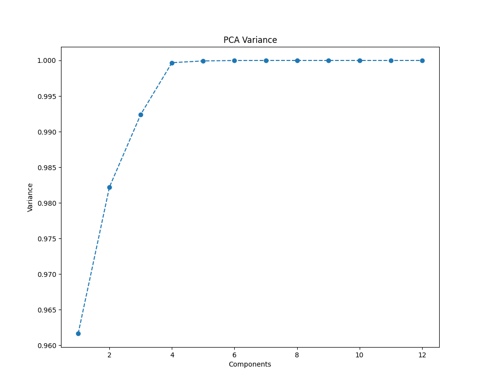

```python
# Plot the variance
plt.figure(figsize = (10,8))
plt.plot(range(1,13), pca.explained_variance_ratio_.cumsum(), marker = 'o', linestyle = '--')
plt.title('PCA Variance')
plt.xlabel('Components')
plt.ylabel('Variance')
```

Looks like **3 components** is the sweet spot where we are still explaining almost all the variance, but with a graph-able amount of features. Let's fit the PCA instance again using just three components:

```python
# Fit PCA with three components
pca = PCA(n_components = 3)
pca.fit(features_norm[var_norms])
features_pca = pca.transform(features_norm[var_norms])
print(features_pca)
```

```
[[-2.23649828e-01  9.32164369e-03 -5.37069105e-03]
 [-2.23669656e-01  9.03550910e-03 -6.48208164e-03]
 [ 7.39721451e-01  1.47304540e-01 -1.03431528e-02]
 ...
 [-1.63405439e-01 -1.16369802e-02  4.49047964e-04]
 [ 5.69497768e-01  3.03924062e-02  6.23676666e-02]
 [-2.23482395e-01  1.14908969e-02  3.08719212e-03]]
```

And let's get those components back into the original dataframe:

```python
features = pd.concat([features, pd.DataFrame(features_pca,columns=['Component1','Component2','Component3'])], axis=1)
```

## 3. Silhouettes and Elbows

Now that we've reduced our features down to just a handful of components, we need to identify the ideal number of clusters for our dataset as in K-Means we don't know in advance how many clusters to use. Luckily, there are a few methods we can use to figure that out - the **Elbow Method**, and the **Silhouette Method**.

Let's start with the **Elbow Method**, which works by plotting the explained variance of the model vs. the number of *k* clusters, and then finding the *elbow* of the curve as the number of clusters to use.

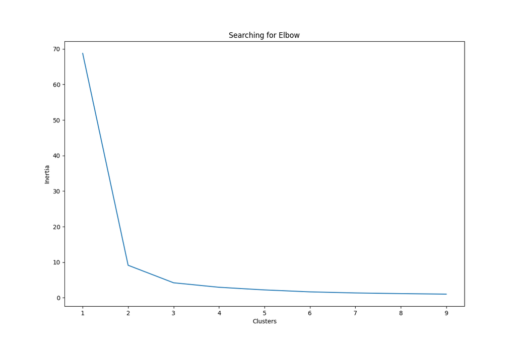

```python
# Find elbow bend
clusters = []

for i in range(1, 10):
    km = KMeans(n_clusters=i).fit(features_pca)
    clusters.append(km.inertia_)

# Plot on graph
fig, ax = plt.subplots(figsize=(12, 8))
sns.lineplot(x=list(range(1, 10)), y=clusters, ax=ax)
ax.set_title('Searching for Elbow')
ax.set_xlabel('Clusters')
ax.set_ylabel('Inertia')

plt.show()
```

Based on this elbow curve graph, it looks like there is a big jump in explained variance after two clusters, another little jump going to three clusters, and then diminishing returns after that. This seems to indicate that three clusters might be the best route to go. However, we can try another test, which is the **Silhouette Method**

The Silhouette Method works by iterating over a range of potential cluster counts, we apply the KMeans algorithm and calculate the *Silhouette Score* for each configuration. This score is a measure of how self-contained the data is within each potnetial number of clusters.

```python
silhouette_scores = []

# Calculate silhouette score for each possibility between 2 and 11 clusters
for num_clusters in range(2, 11):
    kmeans = KMeans(n_clusters=num_clusters, random_state=0)
    kmeans.fit(features_pca)
    labels = kmeans.labels_
    silhouette_avg = silhouette_score(features_pca, labels)
    silhouette_scores.append(silhouette_avg)
```

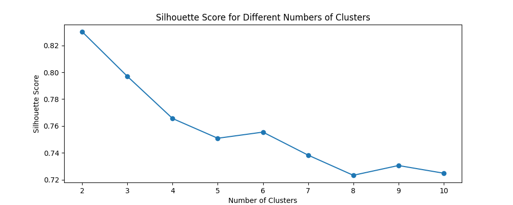

```
Optimal Number of Clusters: 2
```

```python
# Plot silhouette scores
plt.figure(figsize=(10, 4))
plt.plot(range(2, 11), silhouette_scores, marker='o')
plt.title('Silhouette Score for Different Numbers of Clusters')
plt.xlabel('Number of Clusters')
plt.ylabel('Silhouette Score')
plt.show()

# Choose the optimal number of clusters based on the silhouette score
# Add 2 because range starts from 2
optimal_num_clusters = silhouette_scores.index(max(silhouette_scores)) + 2
print(f"Optimal Number of Clusters: {optimal_num_clusters}")
```

Based on this graph, 2 clusters seems to be the most distinct cluster arrangement. However, I am looking to have a few more segments than that, so I am going to go with **4** clusters for this exercise as there is minimal tradeoff in variance between 2 clusters and 4.

## 4. Running KMeans

Alright, now that we've settled on our number of clusters, it's time to run the KMeans model. We'll use four clusters, fit the model on the principal components data, and then impute the resulting clusters back into the dataframe.

```python
# Run KMeans with four clusters
kmeans = KMeans(n_clusters = 4, random_state = 0, n_init='auto')
model = kmeans.fit(features_pca)

# Create labels and dataframe
clusters = pd.DataFrame(model.labels_,columns=['Cluster'])
features = pd.concat([features, clusters], axis=1)

features.head()
```

|  | Rider ID | First Name | Last Name | Number of Rides | Number of Locations | Number of Rides - Last Month | Number of Rides - Last Three Months | Number of Rides - Last Six Months | Number of Rides - Last Twelve Months | Days Between First and Last Ride | Days Since First Ride | Days Since Last Ride | Average Days Between Rides | Average Weeks Between Rides | Rides per Month | Component1 | Component2 | Component3 | Cluster |
| --- | --- | --- | --- | --- | --- | --- | --- | --- | --- | --- | --- | --- | --- | --- | --- | --- | --- | --- | --- |
| 0 | 404 | Eric | Derehow | 1 | 1 | 0 | 0 | 0 | 0 | 0 | 177 | 177 | 0 | 0 | 0.166667 | -0.223650 | 0.009322 | -0.005371 | 0 |
| 1 | 308 | Glen | Palkidis | 1 | 1 | 0 | 0 | 0 | 0 | 0 | 233 | 233 | 0 | 0 | 0.125000 | -0.223670 | 0.009036 | -0.006482 | 0 |
| 2 | 171 | Jim | McRlwain | 30 | 1 | 0 | 0 | 0 | 0 | 322 | 334 | 12 | 10 | 1 | 2.727273 | 0.739721 | 0.147305 | -0.010343 | 3 |
| 3 | 224 | Mac | Loberts | 3 | 1 | 0 | 0 | 0 | 0 | 161 | 299 | 138 | 53 | 7 | 0.272727 | 0.343007 | -0.084189 | -0.008209 | 2 |
| 4 | 8 | Jody | Carpa | 2 | 1 | 0 | 0 | 0 | 0 | 7 | 585 | 578 | 3 | 0 | 0.095238 | -0.213833 | 0.004684 | -0.008358 | 0 |

We can also pull out the cluster centroids, which are the mean values for each cluster.

```python
# Get centroids
centroids = kmeans.cluster_centers_
print(centroids)
```

```
[[-2.09963064e-01  6.34092666e-03  6.38758930e-04]
 [ 5.11285512e-01 -5.36783735e-02  1.21098890e-02]
 [ 2.17028349e-01 -7.08693856e-02 -8.41706273e-03]
 [ 7.03102118e-01  7.01608045e-02 -7.03493209e-03]]
```

And let's see how many riders fall into each cluster:

```python
print(features['Cluster'].value_counts())
```

```
Cluster
0    397
3     62
2     56
1     54
Name: count, dtype: int64
```

It looks like most of my riders fall into Cluster "0", with a relatively equal amount of the remaining riders falling into each of Clusters "1", "2", and "3".

## 5. Model Evaluation

There are a number of ways we can evaluate the effectiveness of the KMeans model that we've created. One is to return to the *silhouette scores* from Section 3 - we can calculate that metric one more time for our final model to see how self-contained the data is within each cluster. We generally want a minimum score of **0.5** for the model to be usable, and a score of **0.7** or more indicates a very good fit on our data.

```python
print('Silhouette Score: ' + str(silhouette_score(features_pca, kmeans.fit_predict(features_pca))))
```

```
Silhouette Score: 0.7657167557540465
```

A silhouette score of **0.76** indicates a very good fit!

We can also try plotting everything on a graph to see how the clusters look. We'll first bring in the functions I've used in the past for generating hover annotations - credit for these goes to this documentation: https://mplcursors.readthedocs.io/en/stable/examples/dataframe.html

```python
# Function to define hover annotations
def show_hover_panel(get_text_func=None):
    cursor = mplcursors.cursor(
        hover=2,  # Transient
        annotation_kwargs=dict(
            bbox=dict(
                boxstyle="round,pad=0.3",
                facecolor="yellow",
                alpha=0.9,
                linewidth=0.5,
            ),
            linespacing=1.5,
            fontsize=8,
            ha="left", va="bottom",
            arrowprops=dict(arrowstyle="->", color='black')
        ),
        highlight=True,
        highlight_kwargs=dict(linewidth=2),
    )

    if get_text_func:
        cursor.connect(
            event="add",
            func=lambda sel: sel.annotation.set_text(get_text_func(sel.index)),
        )
    return cursor
```

```python
# Function to define annotation contents
def on_add(index):
    rider = features.iloc[index]
    parts = [
        f"{rider['First Name']} {rider['Last Name']}",
        f"Cluster: {rider['Cluster']}",
        f"Number of Rides: {rider['Number of Rides']}",
        f"Days Since Last Ride: {rider['Days Since Last Ride']}",
        f"Days Since First Ride: {rider['Days Since First Ride']}",
    ]
    return "\n".join(parts)
```

And now, the graph:

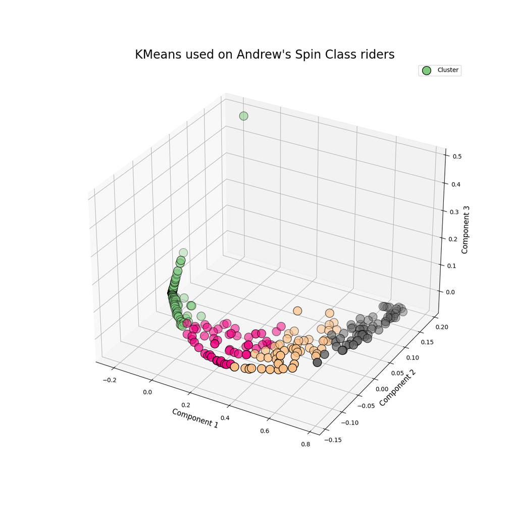

```python
%matplotlib ipympl

fig = plt.figure(figsize=(12,12))
plt.rcParams['font.size'] = 10
ax = plt.axes(projection='3d')
x_points = features[['Component1']]
y_points = features[['Component2']]
z_points = features[['Component3']]
c = features[['Cluster']]
cmap = 'Accent'
s = 200
f1=ax.scatter(x_points, y_points, z_points, c=c, cmap=cmap, s=s, edgecolors='black');

ax.set_xlabel('Component 1', fontsize = 12)
ax.set_ylabel('Component 2', fontsize = 12)
ax.set_zlabel('Component 3', fontsize = 12)
ax.legend(c)

plt.title("KMeans used on Andrew's Spin Class riders",fontsize = 20)
show_hover_panel(on_add)
plt.show()
```

You can see how the four clusters are distributed across each of our components. Hovering over each point will give you the name of the particular rider and some of their key statistics.

Let's take a closer look at the makeup of each individual cluster using boxplots from Python's Seaborn library. First up, **Cluster "0"**:

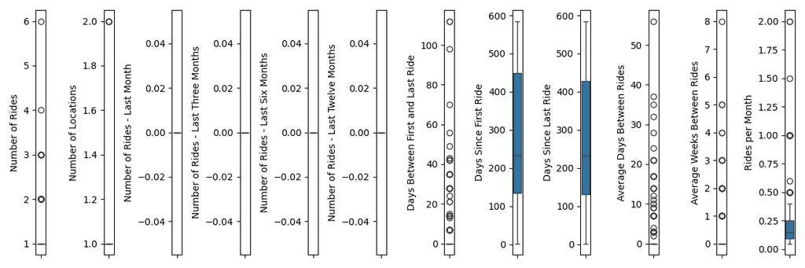

```python
%matplotlib ipympl

# Filter for Cluster 0
cluster_0 = features.loc[features['Cluster'] == 0]

# Create boxplots for each feature
fig, ax = plt.subplots(nrows=1, ncols=12, figsize=(12,4))
for i, col in enumerate(cluster_0[var_norms]):
   sns.boxplot(data=cluster_0[[col]],y=col, ax=ax[i])

# Show plots
plt.tight_layout()
#plt.title("Cluster 0 - 'One-and-Dones'", fontsize = 20)
plt.show()
```

Let's see how **Cluster "1"** compares:

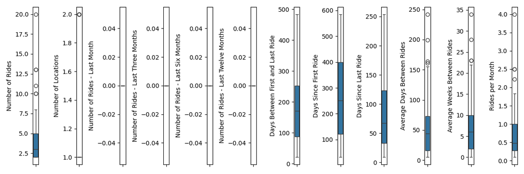

```python
%matplotlib ipympl

# Filter for Cluster 0
cluster_1 = features.loc[features['Cluster'] == 1]

# Create boxplots for each feature
fig, ax = plt.subplots(nrows=1, ncols=12, figsize=(12,4))
for i, col in enumerate(cluster_1[var_norms]):
   sns.boxplot(data=cluster_1[[col]],y=col, ax=ax[i])

# Show plots
#plt.title("Cluster 1 - 'Occasional/Recent Returnees'", fontsize = 20)
plt.tight_layout()
plt.show()
```

Now here's **Cluster "2"**:

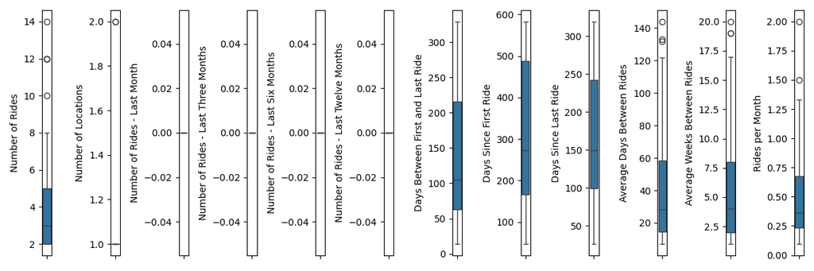

```python
%matplotlib ipympl

# Filter for Cluster 0
cluster_2 = features.loc[features['Cluster'] == 2]

# Create boxplots for each feature
fig, ax = plt.subplots(nrows=1, ncols=12, figsize=(12,4))
for i, col in enumerate(cluster_2[var_norms]):
   sns.boxplot(data=cluster_2[[col]],y=col, ax=ax[i])

# Show plots
#plt.title("Cluster 2 - 'Lapsed Regulars'", fontsize = 20, loc='left')
plt.tight_layout()
plt.show()
```

And finally, **Cluster "3"**:

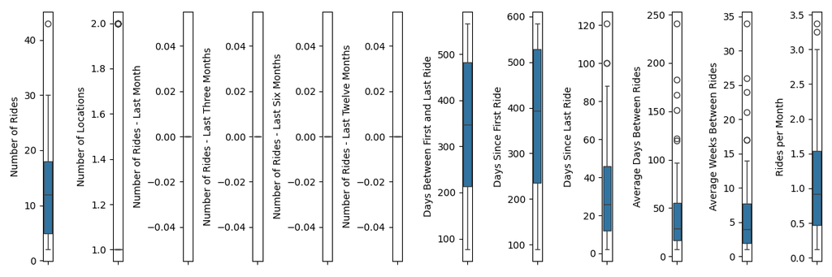

```python
%matplotlib ipympl

# Filter for Cluster 0
cluster_3 = features.loc[features['Cluster'] == 3]

# Create boxplots for each feature
fig, ax = plt.subplots(nrows=1, ncols=12, figsize=(12,4))
for i, col in enumerate(cluster_3[var_norms]):
   sns.boxplot(data=cluster_3[[col]],y=col, ax=ax[i])

# Show plots
plt.tight_layout()
#plt.title("Cluster 3 - 'House Riders'", fontsize = 20, loc='left')
plt.show()
```

**Cluster "3"** consists of my most regular riders. These folks have come back again and again, with most of them having taken between 6 and 18 rides with me. In many cases they have been riding with me for a long time, with most of their first ride dates being between 7 months to over a year ago. But they haven't stopped coming in either, with most of them having been in within the last 1.5 months. They tend to take at a minimum one ride every other month, with some of them coming in as many as three times per month. My goal as an instructor should be to get as much of my rider base as I can into this group.

And that concludes this exercise! The final thing I'll do is to cache this KMeans model so I can use it as part of a regularly-scheduled segmentation process.

```python
# Serialize KMeans Model
joblib.dump(kmeans, 'KMeans_Spin.pkl')

# Serialize PCA
joblib.dump(pca, 'PCA_Spin.pkl')
```